# Creating Enhancenment to improve learner’s productivity and studying experience for Monash’s micro-credential course

ETC5543 Internship Report for Thomas Winson (Nguyen Dang Thanh)

Dang Thanh Nguyen

2021-11-08

# 1 Introduction

## 1.1 Background

From 8 September to 2 November 2021, the author worked on the **Monash University’s Data Science: Data-Driven Decision Making** micro-credential on FutureLearn, under the supervision of Rowan Peter from the host organisation (Monash Centre for Professional Development and Monash Online Education, informally referred to as the Centre).

Offered by the Monash School of Business and led by Professor Dianne Cook, the Data Science: Data-Driven Decision Making is an online postgraduate micro-credential program comprising three courses at Level 8 of the Australian Qualifications Framework. The micro-credential guide learners through practical programming exercises in R language to learn the process of tidying, harvesting and wrangling data and applying statistical models to simulate complex functions that solve a broad range of problems.

## 1.2 Motivation

The assets the author created include written types (code chunks and worked examples) and media types (Tutorial with screen recording).

## 1.3 Objectives

Because of the nature of the internship (creating enhancements for an existing micro-credential), assets created vary greatly in content, goals and difficulty. However, every asset needs to satisfy the common objectives: It must relate to the concepts and learning outcomes of its respective course.

Each course will also satisfy different objectives, depending on the nature of the material.

### 1.3.1 Common objectives

The assets were crafted with the nature of micro-credential in mind. All the assets are related to the concepts and learning outcomes of their respective course. Furthermore, The assets need to maximise user experiences. In detail, the “difficulty” of the assets is modified depending on the nature of the course. For example, assets in the first course use simpler words, together with very detailed explanations and comments that can be lengthy to some learners. Those assets also don’t include new concepts that were not introduced in the material. In courses 2 and 3, explanations and comments are more concise. Academic words are used more frequently in those courses. New concepts are introduced when needed (e.g: Using package patchwork to combine graphs).

### 1.3.2 Specific objectives

Given the wide variety in contents of each asset, an one-size-fits-all objective may not be suitable. A range of specific objectives is created to assess each enhancement created. All assets have an aim to satisfy as many specific objectives as possible. Overall, the specific objectives aim to maximise learners’ studying experience and to provide knowledge that can be applied in future real-life cases that the learners will eventually face.

Detailed information of specific objectives are as follow:

1. Creating well-documented and well-explained assets that support new learners with no background in statistics and R-coding.
2. Delivering cutting edges techniques that learners can apply in solving problems.
3. Providing detailed examples and code that learners can duplicate in their work.
4. Supplying functional practices that can improve learners’ productivity.

## 1.4 Contribution

Based on recommendations and feedback from the micro-credential course team and learners, the author crafted enhancements that fill the gap in pre-existing material, thus improving the value of the micro-credential. Furthermore, the author wrote the assets with the learner’s studying in mind and compared that with his own personal experience in learning R to deliver unique written and media materials. These are valuable properties for the course that will assist learners in gaining the skills that they need to apply for roles like data scientist or use the knowledge gained to enhance their current organisation.

## 1.5 Methodology

The assets created in the internship are based on the tidyverse approach. All of the new material utilised already-in-use datasets, creating a smooth transition between old and new sessions. As each asset focuses on a different part of the course, further information is provided in the corresponding section.

## 1.6 Limitations

# 2 Assets developed for the internship:

Based on the analysis of existing materials, recommendations and feedback from the micro-credential course team (Professor Cook, Jiaying Wu and Rowan Peter) as well as documented learner anecdotes), the author has designed and developed the following new enhancements (assets):

## 2.1 Asset 1: Functions (Written + Tutorial)

In the first course, Wrangling and Workflow, of the micro-credential, the material teaches the learners to use functions to solve statistical problems. However, the author believes this approach is not suitable. Many learners don’t have a background in statistics or math, so they are not interested in using functions in this fashion. Furthermore, various pre-written packages also supply a wide range of functions for this purpose.

Another way of using functions, as tools to avoid repetition, should be taught. The learners can apply the knowledge immediately to improve their productivity. Therefore, the author created a new section to teach the learners about function as a tool to automate common tasks. The author also provided a tutorial for this asset.

### 2.1.1 Asset summary

Dataset: [Tuberculosis dataset](https://github.com/datascienceprogram/ids_course_data/blob/master/tb_tidy.rds) from the previous part of the course.

Specific objectives satisfied: Objectives 1, 2, 3 and 4.

#### 2.1.1.1 Key contributions:

1. Provide reasons to apply function as a tool to automate common tasks.
2. Teach learners how to write functions and examples.
3. Introduce curly curly “{{ }}” to combine tidyverse wrangling verbs and function.
4. Provide tutorial video with screen recording.

### 2.1.2 The asset in detail:

#### 2.1.2.1 Why should you use function?

Functions are powerful ways to automate your tasks. You will become more productive using function.

1. Function enable easy reuse within a project, helping you not to repeat yourself. Use function whenever there is a need to copy and paste a block of code more than twice.
2. Function eliminates the chance of making incidental mistakes when you copy and paste (i.e. updating variable names in several places).
3. Function can be given an evocative name that makes your code easier to understand.
4. Function will help you to effortlessly update your code as requirements change.

#### 2.1.2.2 How to write function:

1. Pick a short but informative name, preferably a verb.
2. List inputs, or arguments, inside the round brackets inside function. If we had more the call would look like function(x, y, z).
3. Place the code you have developed in body of the function, a {} block that immediately follows function(…).

Note that, is is easier to start with working code and turn it into a function; it’s harder to create a function and then try to make it work.

Example:

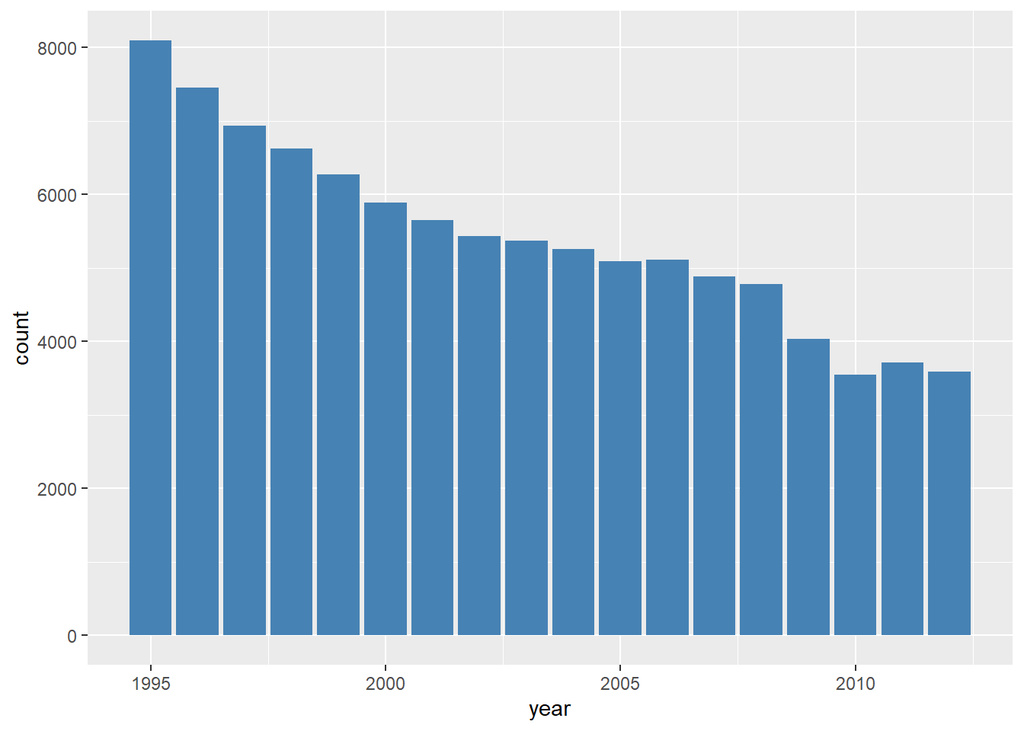

```r
# Function to make a bar chart to see the number of cases of tuberculosis across years for a specific country.
# Identify inputs: data and a country name.
# First argument (x) is data
# Second argument (y) is the country we want to draw the graph for (Must be inside double quotation mark)

# Make our function easier to read
# And change the color
plot_a_country <- function(data, country_name){
  # Filter the country
  plot_dat <- data %>% filter(country == country_name)
  # Draw the plot
  plot <- plot_dat %>%
    ggplot(aes(x = year, y = count))+
    geom_col(fill = "steelblue")

  return(plot)

}
# Checking the function
# The function works as "United States of America" is a valid country name.
plot_a_country(tb_long, "United States of America")
```

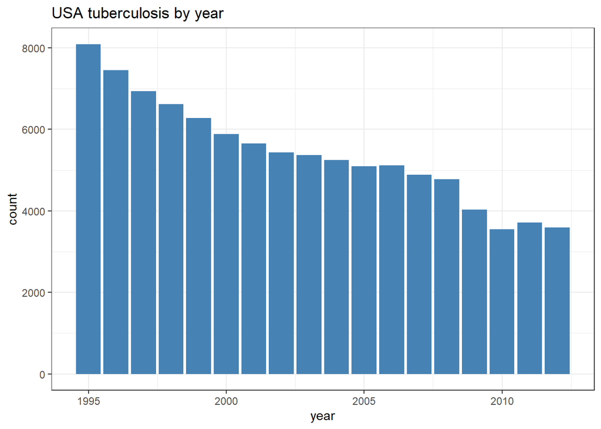

```r
# You can further modify the plot after using the function
plot_a_country(tb_long, "United States of America") +
  theme_bw()+
  ggtitle("USA tuberculosis by year")
```

#### 2.1.2.3 About curly curly {{}}

It was hard to write function with tidyverse wrangling verbs. R will throw all type of error at you. You couldn’t easily use select(), summarise(), group_by() inside a function. Curly curly helps with that. It work *within* the function.

When you create a function using select(), summarise(), group_by(), wrap the function arguments containing data frame variables with {{.

Examples:

```r
# You can not run this function if you remove the curly curly

# Function to find the total cases by country since first recorded

total_by <- function(data, var, by) {
  data %>%
    group_by({{by}}) %>%
    summarise(total_cases = sum({{var}}, na.rm = TRUE)) %>%
    arrange(desc(total_cases))
}

# Checking the function
total_by(tb_long,count, country) %>% head(10) %>%
  kable(caption = "Top 10 countries with highest total cases of tuberculosis since first recorded") %>%
  kable_styling(bootstrap_options = c("striped", "hover", "condensed")) %>%
  scroll_box(height = "300px")
```

Table 2.1: Top 10 countries with highest total cases of tuberculosis since first recorded

| country | total_cases |
| --- | --- |
| India | 6492850 |
| China | 5643738 |
| Indonesia | 1886657 |
| South Africa | 1435147 |
| Bangladesh | 1072431 |
| Viet Nam | 915525 |
| Democratic Republic of the Congo | 889682 |
| Philippines | 858492 |
| Pakistan | 826354 |
| Brazil | 600729 |

## 2.2 Asset 2: Base R, R Operators, Syntax, Shortcuts. Introduce to knitr chunk options (Written)

There is a gap in the existing material: The use of Operators, Syntax, Shortcuts and knitr chunk options are not mentioned in the course. In the author’s belief, they are useful resources that can improve productivity. Therefore, the author created this asset as a “further reading” section, especially for new learners that have no knowledge in R. It is a collection of shortcuts, syntax and operators that the author found handy. It will act as a “cheat sheet” that the learners can come back and read again from time to time. This “cheat sheet” saved the author a large amount of time and make him more productive. It also makes coding with R smoother. In composing this part, the author hopes that the learners can apply the knowledge here in their future works and projects.

For the base R syntax, they confused me when the author first learned them. Since they are all over StackOverflow and the internet, the learners will stumble on them sooner or later. They are old and not used much, and thus are not taught in the course. However, the author figured that knowing the basics of base R may help the learners with their learning and handling assignments, and eventually to solve real-life problems that they will face in the future.

### 2.2.1 Asset summary

Data: No data was used. Objective satisfied: Objective 1, 3 and 4.

#### 2.2.1.1 Key contributions

1. Provide tables for operators, syntax and shortcuts that help learners in improving their productivity.
2. Introduce learners to base R syntax.
3. Introduce learners to chunk’s options in knitr and Rmarkdown.

### 2.2.2 The asset in detail

The asset contains a large amount of text and tables, which may interrupt the overall flow of the report. Furthermore, it is nearly impossible to fit in this section as the asset contains an extensive number of headings. See Appendix 1 for more detail of the asset.

## 2.3 Asset 3: Git and GitHub functionality (Tutorial)

In course 1, there is material about setting up Git and GitHub version control in RStudio. However, there is no material to instruct learners what to do after that, i.e how to use Git and Github studio terminal in R. This created a gap that needs to be fulfilled.

### 2.3.1 Asset summary

1. Introduce learners to Git and Github workflow
2. Introduce learners to git commands to interact with GitHub using the Terminal:

### 2.3.2 The asset in detail

#### 2.3.2.1 Git and Github Workflow

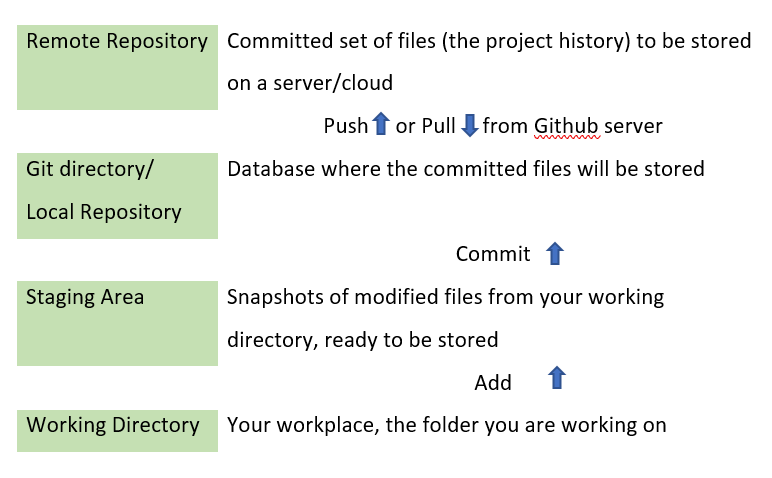

Figure 2.1: Git and Github version control system

Figure 2.1 shows the three-states system of Git with the addition of the remote repository from Github.

#### 2.3.2.2 List of Git commands

• git pull (Download content from a remote repository and immediately update the local repository to match that content).  
• git status (The git status command displays the state of the working directory and the staging area).  
• git add file_name (Add a change in the working directory to the staging area, you need to specify the file).  
• git add . (Add all changes in the working directory to the staging area. Be careful with it.).  
• git commit -m “Message” (m = message for commit. The git commit is used to create a snapshot of the staged changes along a timeline of a Git projects history).  
• git push origin (push/ upload the local repository content to a remote repository).

## 2.4 Asset 4: Sample assignment (Written)

My supervisor, Rowan Peter, suggested that an example for the first assignment of the micro-credential is needed, as the works that learners suggest varied largely in contents, methods and quality. Furthermore, an example that acts as an exemplar for learners is desired, as this may help to guide them in further projects. The example also introduces learners to a standard report, which need to have a logical flow and graphs with proper title and labels.

The sample assignment can be of great use for learners. Not only does it act as an example for their work, it also provides good practices to the learners. An example is to provide appropriately labelled visualisation. Another example is the practice of cleaning and checking the data before any analysis and reporting only interesting results/ findings.

Specific objectives satisfied: Objectives 1, 2, 3 and 4.

#### 2.4.0.1 Key contributions

1. Provide assignment examples with a nice flow and well-structured sections.
2. Provide code chunks that only use functions and knowledge covered by the first course.
3. Provide well-documented code, and have high production values. The code can be re-used or duplicated in later projects.

#### 2.4.0.2 The asset in detail

As the asset has its structure, including it in this section will heavily disrupt the flow of the report. Therefore, the asset is put in Appendix 2.

## 2.5 Asset 5: KNN imputation and survivorship bias (Written)

In Course 2, Modelling and Visualisation, learners are introduced to missing values. Two gaps need improvement in this course:

Firstly, the introduction is neither informative nor engaging Moreover, many explanations are vague and use words that are different from previous parts (“Cases” instead of “Observations”), which negatively affects the learner’s experience.

Secondly, many learners struggled with neighbour imputation implementation on Step 1.16. “Dealing with missing data.” The “bioconductor” package used in the section is outdated and hard to install. Furthermore, the material of this part is not documented, making it hard to understand.

### 2.5.1 Asset summary

Dataset: oceanbuoys from package Tierney et al. (2021).  
Objective 1, 2, 3 and 4

#### 2.5.1.1 Key contributions:

1. Highlight the problems of missing values in real life, with survivorship bias and the Challenger disaster as examples.
2. Replace the old knn_imputation method with a more advanced tidymodels approach.
3. Provide a better explanation and more documents for code chunks, provide discussion for KNN- imputation result.
4. Rewrite parts of the existing materials, uniform the use of terms and add a comparison of imputation methods to improve user experience.

### 2.5.2 Comparision old material and new material

Old code has several problems:

- Very hard to install the package.
- The package is outdated.
- Very hard to understand the codes since there are no comments, no result and no discussion.

```r
# old code

# Very hard to install the package
 if (!requireNamespace("BiocManager", quietly = TRUE))
    install.packages("BiocManager")
 BiocManager::install("impute", version = "3.10")


# No comments whatsoever
# Very hard to follow
library(impute)
tao_impute <- bind_shadow(oceanbuoys) %>%
  arrange(year, sea_temp_c, air_temp_c) %>%
  select(sea_temp_c, air_temp_c)
tao_impute <- impute.knn(as.matrix(tao_impute), 5)
tao_shadow <- bind_shadow(oceanbuoys) %>%
  arrange(year, sea_temp_c, air_temp_c) %>%
  mutate(sea_temp_c = tao_impute$data[,1],
         air_temp_c = tao_impute$data[,2])
ggplot(tao_shadow,
       aes(x = sea_temp_c,
           y = air_temp_c,
           colour=air_temp_c_NA)) +
  geom_point(alpha=0.7) +
  facet_wrap(~year) +
  scale_colour_brewer(palette="Dark2") +
  theme(aspect.ratio=1)
```

New Code: - Using tidymodels package which is more advanced and esier to install. - There are comments and discussion of results, making the code easier to understand and improve learner’s experience.

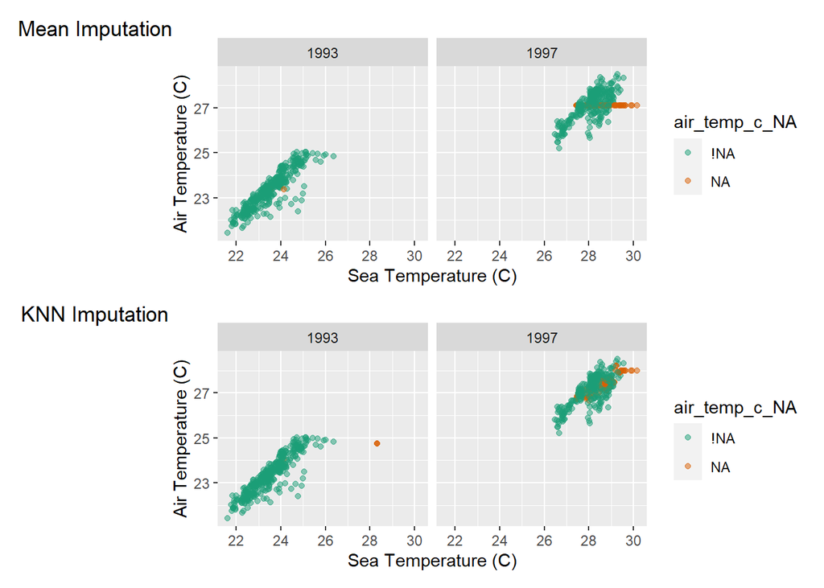

Figure 2.2: Mean Imputation VS KNN Imputation

```r
# New code

# Install and load tidymodels
# install.packages("tidymodels")
library(tidymodels)

tao_shadow <- bind_shadow(oceanbuoys)
impute_rec  <- tao_shadow %>%
  # In recipe, choose the variable that we will use. In this case:
  # year, sea_temp_c, air_temp_c, air_temp_c_NA
  recipe(year~ sea_temp_c+air_temp_c+air_temp_c_NA) %>%
  # Impute the missing values with all predictors
  step_impute_knn(sea_temp_c,air_temp_c)


# get the imputed data out using juice()
# You can use bake() to apply the recipe to other dataset. (Eg. New dataset)
imputed <- prep(impute_rec) %>% juice() %>%
  mutate(id = row_number())

## Draw the plot
knn_impute_plot <- ggplot(imputed,
       aes(x = sea_temp_c,
           y = air_temp_c,
           colour=air_temp_c_NA,
           group = id)) +
  geom_point(alpha=0.5) +
  facet_wrap(~year) +
  scale_colour_brewer(palette="Dark2")+
    ## Add a tag and label for both axis
  labs(tag = "KNN Imputation")+
  xlab("Sea Temperature (C)")+
  ylab("Air Temperature (C)")

# Compare 2 methods of imputation using patchwork package
#Install patchwork
# Install.packages("patchwork")

## Patchwork allows us to combine ggplots into 1 graphic.
library(patchwork)

# Display both graphs
mean_impute_plot / knn_impute_plot
```

The imputed values are **closer** to the complete case values in both methods. However, for the mean imputation method, the data points form a rigid line, mismatching the variation. They also extend outside the range of complete values. For the KNN method, the values blended well with the complete values. There is still a rigid line that extends outside of the range of complete values in KNN imputation. This can happen if all of the points missing on air temp (ones with high values on sea temp) have the exact same nearest neighbours. If we increase k, to add more nearest neighbours, eventually the line should break. However, there are multiple missings at extremes of sea temp so the line is probably as good as can be done by nearest neighbours.

There is a problem: the imputed air temperature value for these high sea temperature cases is **lower** than expected for both mean imputation and KNN imputation. There is also an outlier in 1993 for KNN imputation. It is suspected that this point should be a 1997 record and there has to be an error in the data. These findings may possibly impede good model fitting.

## 2.6 Asset 6: Wordcloud (Written)

In course 3, learners are taught how to visualise text data using ggplot and geom_points. However, there is another approach in visualising text data that is not mentioned. Therefore, the author created this section about using word clouds to visualise text data. Word clouds are very useful as they provide a simple and clear presentation of text data, presenting frequently used keywords bigger and bolder than the rest. As such, they are very easy and quick to understand. Furthermore, word clouds are visually engaging, which allow us to draw multiple insights quickly and allow us flexibility in interpretation.

Dataset: Text data from “On the Origin of Species,” 1st edition (Charles Darwin) from package gutenbergr

Objective satisfied: Objective 1, 3 and 4.

#### 2.6.0.1 Key contribution:

1. Introduce learners to 2 ways of drawing word cloud in R.
2. Provide codes, comments and discussion for graphs created.

#### 2.6.0.2 The asset in detail:

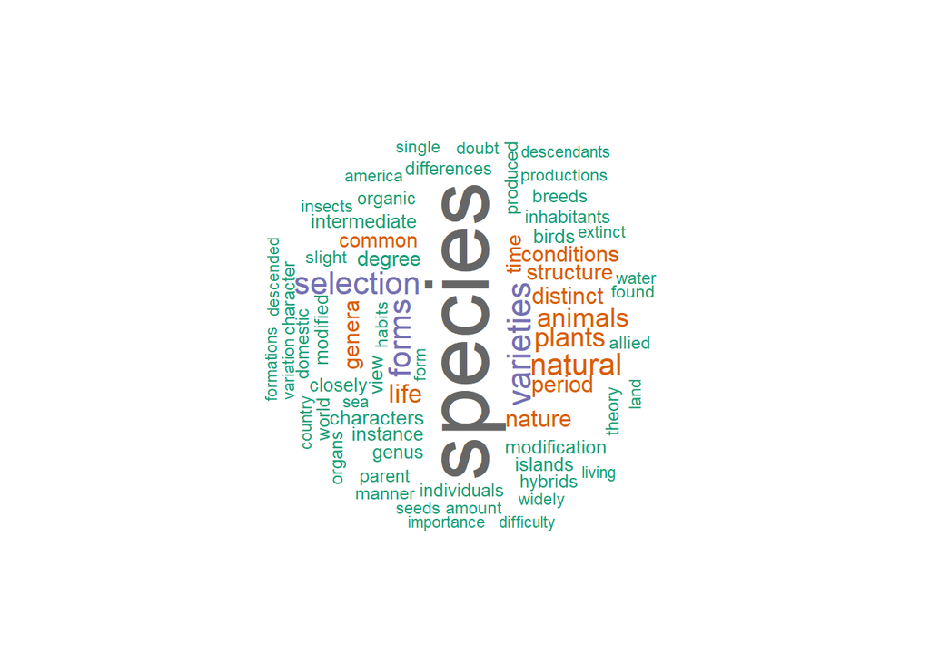

Figure 2.3: Word cloud of On the Origin of Species, 1st Edition using wordcloud function

```r
# Word cloud using the package wordcloud.
# Make a temporary dataframe, since wordcloud require only 2 columns which are word and freq.
# There are many useful arguments to toggle, try to explore them.
library(wordcloud)
temp <- data.frame(word = darwin1_words$word, n = darwin1_words$n)

# Use wordcloud
wordcloud(words = darwin1_words$word,
          freq = darwin1_words$n,
          min.freq = 100, max.words=200,
          random.order=FALSE, rot.per=0.35,
          colors=brewer.pal(8, "Dark2"))
```

```r
# Assets on creating word cloud

# Wordcloud 2 produce HTML output, suitable when you need to knit your report to html

# Make a temporary dataframe, since wordcloud require only 2 columns which are word and freq.
# Then get the words that appeared more than 100 times
temp <- data.frame(word = darwin1_words$word, n = darwin1_words$n) %>%
 filter(n > 100)

# Use wordcloud2
# Try to change the shape of the cloud. Hint: shape in ?wordcloud2

wordcloud2(temp, size = 0.5, shape = 'star', color = "random-dark")
```

[interactive chart not shown]

Figure 2.4: Word cloud of On the Origin of Species, 1st Edition, using wordcloud2 function

# 3 Conclusion

In conclusion, all of the assets created by the author satisfied the pre-identified common objectives and specific objectives. The material follows strictly the goals of micro-credential: To assist learners in gaining the skills that they need to apply for roles as a data scientist or use the knowledge gained to enhance their current organisation. The author combines his own experience in learning R and a focus on learners’ studying experience to deliver unique written and media materials. These materials are valuable properties for the course that will improve the quality of teaching and the learner’s studying experience.